# Inside Item Recollection

# 3 Novelty Benefits

We hypothesised that the memory for the items outside the rooms should be better for the *novel* rooms than for the *familiar* rooms.

## 3.1 Compare mean accuracy between *novel* and *familiar* rooms

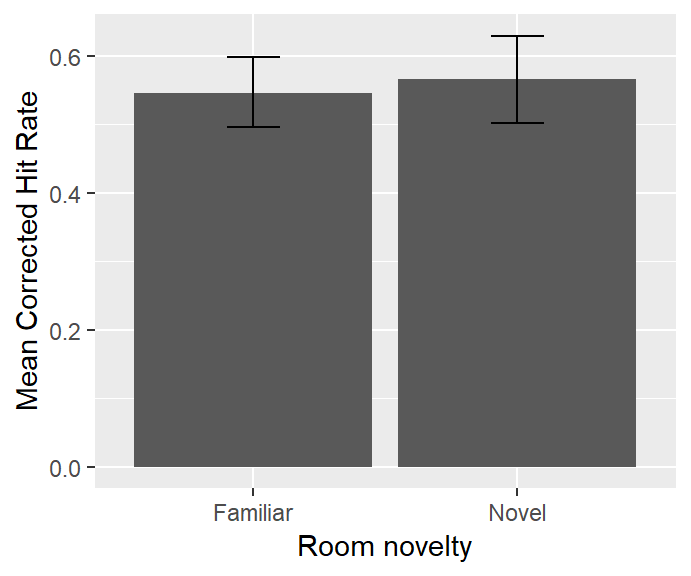

Figure 3. Mean hit rate for recollect response respectively for Familiar and Novel rooms.

```
##
##  Paired t-test
##
## data:  MeanCorrSeenHit by Group
## t = -0.72687, df = 39, p-value = 0.4716
## alternative hypothesis: true difference in means is not equal to 0
## 95 percent confidence interval:
##  -0.07530468  0.03548987
## sample estimates:
## mean of the differences
##             -0.01990741
```

## 3.2 Item memory as a function of item order

### 3.2.1 Visualise the data

#### 3.2.1.1 Nonlinear

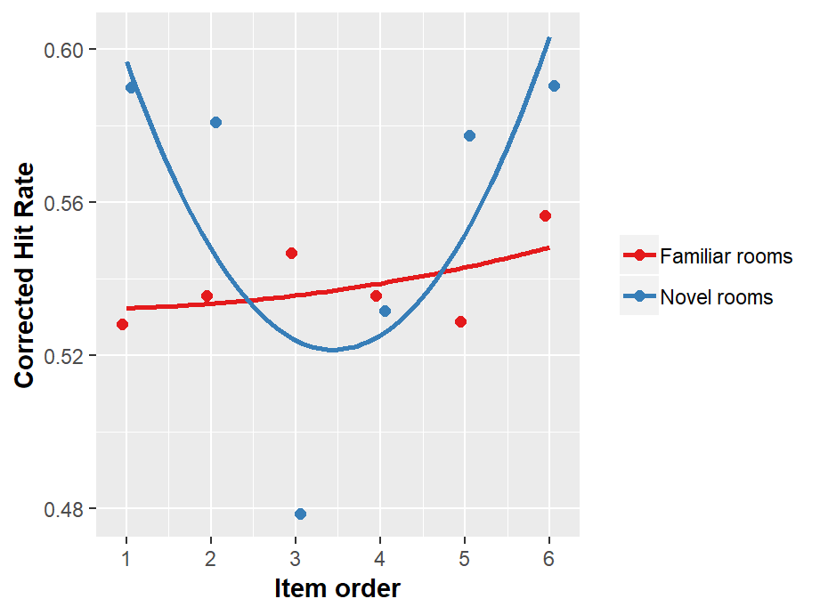

Figure 4. Mean hit rate for seen response at each order (i.e., 1st, 2nd, 3rd, etc), respectively for familiar and novel rooms.

#### 3.2.1.2 Linear

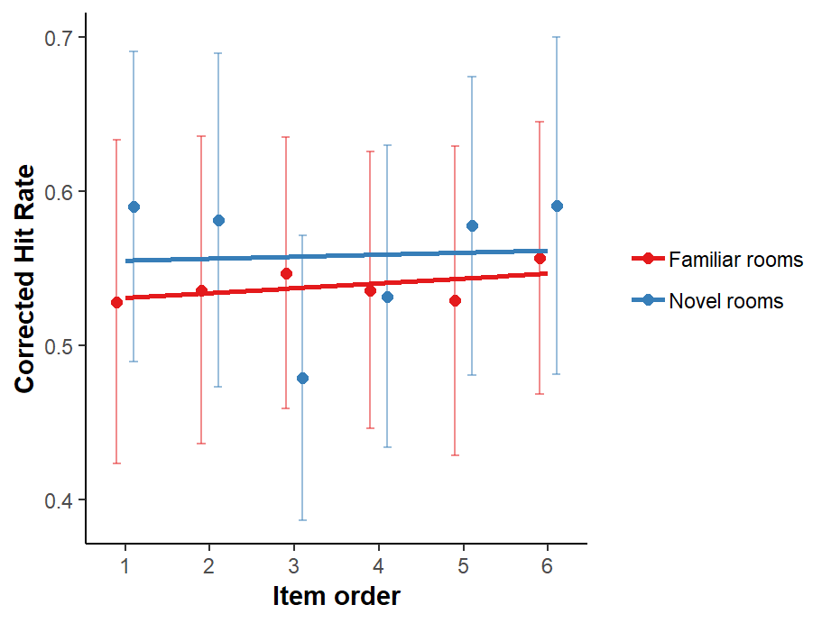

Figure 4. Mean hit rate for seen response at each order (i.e., 1st, 2nd, 3rd, etc), respectively for familiar and novel rooms.

### 3.2.2 Testing novelty effect as a function of item order.

Build models with corrected hit rate as $y$ and then examine effects of novelty by comparing the models.

- `baseline.item` is the model with only an intercept.
- `order.model.linear.1` is the model with $\small ItemOrder$ included, showing the effects of item order.
- `order.model.linear.2` is the model allowing the slope (i.e., relationship between item memory and item order) varying across participants.
- `order.model.quad.1` and `order.model.quad.2` repectively included $\small ItemOrder^2$ and related random effects.
- `novelty.model.1` is the model with $\small Group$ (i.e., *familiar* and *novel* rooms) included, examining the effects of novelty of the rooms on the intercept (i.e., mean item memory accuracy at the 1st order or overall if no difference in slope).
- `novelty.model.2` is the model with interaction between $\small Group$ and $\small ItemOrder$ included, examining the effects of novelty on how item memory accuracy changes as a function of item order.
- `novelty.model.3` included interaction between $\small Group$ and $\small ItemOrder^2$ for inestigating whether the pattern changes between *familiar* and *novel* groups.

```
##                      Model df      AIC      BIC    logLik   Test  L.Ratio
## baseline.item            1  4 152.8736 169.5687 -72.43678
## order.model.linear.1     2  5 154.7706 175.6395 -72.38528 1 vs 2 0.102993
## order.model.linear.2     3  9 157.4375 195.0015 -69.71873 2 vs 3 5.333113
## order.model.quad.1       4  6 154.8843 179.9270 -71.44216 3 vs 4 3.446869
## novelty.model.1          5  7 156.3440 185.5605 -71.17201 4 vs 5 0.540312
## novelty.model.2          6  8 158.3262 191.7165 -71.16312 5 vs 6 0.017779
## novelty.model.3          7  9 158.7153 196.2794 -70.35766 6 vs 7 1.610914
##                      p-value
## baseline.item
## order.model.linear.1  0.7483
## order.model.linear.2  0.2548
## order.model.quad.1    0.3277
## novelty.model.1       0.4623
## novelty.model.2       0.8939
## novelty.model.3       0.2044
```

Nothing significant.

#### 3.2.2.1 Parameter estimation for the complete model

```
##                               Value   Std.Error  DF   t-value      p-value
## (Intercept)              0.59666306 0.045149442 396 13.215292 2.759429e-33
## ItemOrderCt             -0.06141955 0.035115652 396 -1.749065 8.105454e-02
## I(ItemOrderCt^2)         0.01254509 0.006741385 396  1.860907 6.349817e-02
## Group1                  -0.06428346 0.054152801  39 -1.187075 2.423783e-01
## ItemOrderCt:Group1       0.06203215 0.049661031 396  1.249111 2.123622e-01
## I(ItemOrderCt^2):Group1 -0.01203666 0.009533759 396 -1.262531 2.075009e-01
```

### 3.2.3 Collapse the order and novelty group

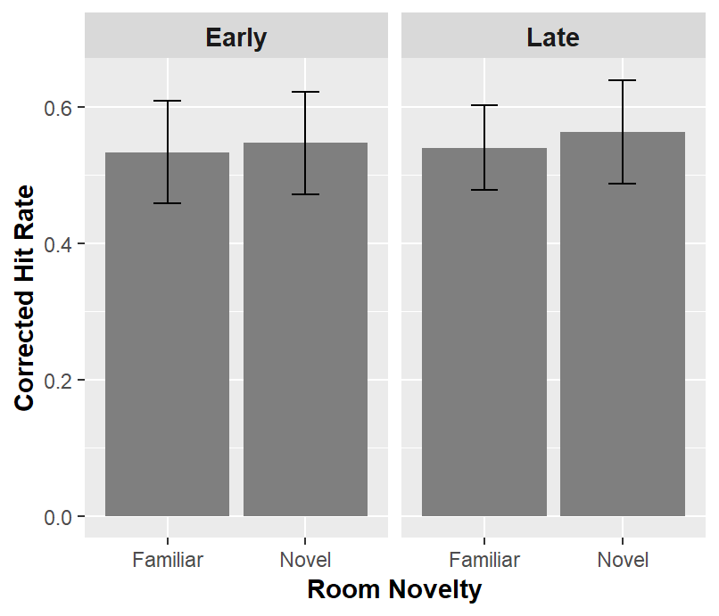

#### 3.2.3.1 Stats on it

```
##               Model df       AIC       BIC   logLik   Test   L.Ratio
## baseline          1  5 -59.25832 -43.88245 34.62916
## NoveltyModel      2  6 -57.71236 -39.26132 34.85618 1 vs 2 0.4540410
## OrderModel        3  7 -55.93758 -34.41136 34.96879 2 vs 3 0.2252187
## repeatedModel     4  8 -53.97380 -29.37241 34.98690 3 vs 4 0.0362176
##               p-value
## baseline
## NoveltyModel   0.5004
## OrderModel     0.6351
## repeatedModel  0.8491
```

No significant main effects or interaction.

# 4 Curiosity Benefits

We hypothesed that the higher the curiosity rating was, the better the item memory should be.

## 4.1 Mean accuracy of item memory as a function of curiosity rating

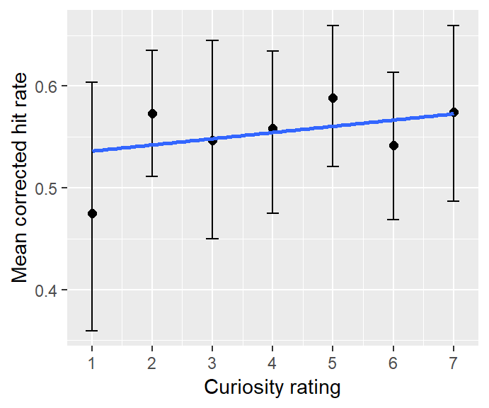

Figure 5. Mean hit rate as a function of curiosity rating.

### 4.1.1 Testing the relationship between mean accuracy of item memory and curiosity rating

Build models with item memory accuracy as $y$ and examine effects of curiosity rating by including it into the model and then comparing the model fits.

- `baseline.rating` is the model with only an intercept, showing no change in item memory as a function of curiosity rating.
- `rating.intercept` is the model with $\small CuriosityRating$ included, showing the effects of curiosity rating.
- `rating.slope` is the model allowing the slope (i.e., relationship between item memory and curiosity rating) varying across participants.

```
##                  Model df       AIC        BIC   logLik   Test   L.Ratio
## baseline.rating      1  3 -23.49593 -13.104434 14.74797
## rating.intercept     2  4 -22.31339  -8.458066 15.15670 1 vs 2 0.8174636
## rating.slope         3  6 -20.18498   0.598012 16.09249 2 vs 3 1.8715855
##                  p-value
## baseline.rating
## rating.intercept  0.3659
## rating.slope      0.3923
```

Not significant.

### 4.1.2 What about normalised curiosity rating?

```
##                  Model df       AIC        BIC   logLik   Test   L.Ratio
## baseline.rating      1  3 -23.49593 -13.104434 14.74797
## rating.intercept     2  4 -21.69745  -7.842127 14.84873 1 vs 2 0.2015241
## rating.slope         3  6 -19.30065   1.482342 15.65033 2 vs 3 1.6031955
##                  p-value
## baseline.rating
## rating.intercept  0.6535
## rating.slope      0.4486
```

Still not significant.

## 4.2 Does the relationship with curiosity rating depend on item order?

### 4.2.1 Curiosity Rating

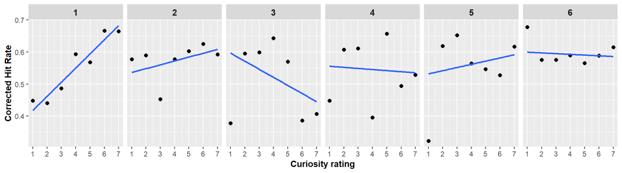

Figure 6. Mean hit rate across participants as a function of curiosity rating for each order at which the item was seen (I.e., 1st, 2nd, 3rd, etc.).

### 4.2.2 Testing the effect of item order

Build models with corrected hit rate as $y$ and examine effects of curiosity rating and item order by comparing the models.

- `item.model.linear.1` is the model with $\small ItemOrder$ included (in addition to $\small CuriosityRating$), showing the effects of item order.
- `item.model.linear.2` is the model allowing the slope (i.e., relationship between item memory and item order) varying across participants.
- `item.model.linear.3` is the model with the interaction between $\small ItemOrders$ and $\small CuriosityRating$ included.
- `item.model.quad.1` and `item.model.quad.2` repectively included $\small ItemOrder^2$ and related random effects.
- `item.model.quad.3` included interaction between $\small ItemOrder^2$ and $\small CuriosityRating$ for inestigating whether the pattern changes as a function of *curiosity rating*.

```r
baseline.item <- lme(CorrSeenHit ~ 1, random = ~ 1|SubjectNo, data = Encoding.Recall.Old.CuriosityRating[!SubjectNo %in% bad.ps.less.strict], method = "ML", control = list(msMaxIter = 500, opt = "optim", msVerbose=FALSE), na.action = na.exclude)

rating.intercept <- update(baseline.item, .~. + CuriosityRating)
rating.slope     <- update(rating.intercept, random = ~ 1 + CuriosityRating | SubjectNo)

item.model.linear.1     <- update(rating.slope, .~. + ItemOrderCt)
item.model.linear.2     <- update(item.model.linear.1, random = ~1+CuriosityRating + ItemOrderCt|SubjectNo)
item.model.linear.3     <- update(item.model.linear.2, .~. + ItemOrderCt : CuriosityRating)

item.model.quad.1       <- update(item.model.linear.3, .~. + I(ItemOrder^2))
# item.model.quad.2       <- update(item.model.quad.1,   random = ~1+CuriosityRating+ItemOrder+I(ItemOrder^2)|SubjectNo) # excluding this model because singularity issue (perhaps the model was getting too complex to be calculated)
item.model.quad.3       <- update(item.model.quad.1,   .~. + I(ItemOrder^2) : CuriosityRating)

anova(baseline.item, rating.intercept, rating.slope, item.model.linear.1, item.model.linear.2, item.model.linear.3, item.model.quad.1, item.model.quad.3)
```

```
##                     Model df      AIC      BIC    logLik   Test  L.Ratio
## baseline.item           1  3 1345.240 1360.351 -669.6201
## rating.intercept        2  4 1346.123 1366.271 -669.0616 1 vs 2 1.117119
## rating.slope            3  6 1348.083 1378.305 -668.0417 2 vs 3 2.039770
## item.model.linear.1     4  7 1349.773 1385.032 -667.8863 3 vs 4 0.310817
## item.model.linear.2     5 10 1353.996 1404.367 -666.9982 4 vs 5 1.776176
## item.model.linear.3     6 11 1353.725 1409.132 -665.8625 5 vs 6 2.271345
## item.model.quad.1       7 12 1353.493 1413.937 -664.7463 6 vs 7 2.232446
## item.model.quad.3       8 13 1351.178 1416.660 -662.5892 7 vs 8 4.314177
##                     p-value
## baseline.item
## rating.intercept     0.2905
## rating.slope         0.3606
## item.model.linear.1  0.5772
## item.model.linear.2  0.6201
## item.model.linear.3  0.1318
## item.model.quad.1    0.1351
## item.model.quad.3    0.0378
```

There was a significant interaction between curiosity rating and item order (quadratic trend), *p* = 0.038.

```r
summary(item.model.quad.3)
```

```
## Linear mixed-effects model fit by maximum likelihood
##  Data: Encoding.Recall.Old.CuriosityRating[!SubjectNo %in% bad.ps.less.strict]
##        AIC     BIC    logLik
##   1351.178 1416.66 -662.5892
##
## Random effects:
##  Formula: ~1 + CuriosityRating + ItemOrderCt | SubjectNo
##  Structure: General positive-definite, Log-Cholesky parametrization
##                 StdDev     Corr
## (Intercept)     0.14796420 (Intr) CrstyR
## CuriosityRating 0.02266063 -0.336
## ItemOrderCt     0.02468386 -0.348  0.191
## Residual        0.41854147
##
## Fixed effects: CorrSeenHit ~ CuriosityRating + ItemOrderCt + I(ItemOrder^2) +      CuriosityRating:ItemOrderCt + CuriosityRating:I(ItemOrder^2)
##                                     Value  Std.Error   DF   t-value
## (Intercept)                     0.4235831 0.06708593 1093  6.314038
## CuriosityRating                 0.0341545 0.01379645 1093  2.475602
## ItemOrderCt                     0.1408637 0.08833378 1093  1.594675
## I(ItemOrder^2)                 -0.0159455 0.01233769 1093 -1.292419
## CuriosityRating:ItemOrderCt    -0.0438640 0.01872899 1093 -2.342039
## CuriosityRating:I(ItemOrder^2)  0.0054313 0.00261879 1093  2.073969
##                                p-value
## (Intercept)                     0.0000
## CuriosityRating                 0.0135
## ItemOrderCt                     0.1111
## I(ItemOrder^2)                  0.1965
## CuriosityRating:ItemOrderCt     0.0194
## CuriosityRating:I(ItemOrder^2)  0.0383
##  Correlation:
##                                (Intr) CrstyR ItmOrC I(IO^2 CR:IOC
## CuriosityRating                -0.860
## ItemOrderCt                    -0.564  0.530
## I(ItemOrder^2)                  0.429 -0.405 -0.977
## CuriosityRating:ItemOrderCt     0.512 -0.577 -0.914  0.895
## CuriosityRating:I(ItemOrder^2) -0.392  0.442  0.894 -0.915 -0.978
##
## Standardized Within-Group Residuals:
##        Min         Q1        Med         Q3        Max
## -1.9899938 -1.0135908  0.3464575  0.8521856  1.7751197
##
## Number of Observations: 1138
## Number of Groups: 40
```

For the first item, there was a significant positive correlation between recollection and curiosity rating, *p* = 0.014. The correlation become weaker for the items that were seen later, both in terms of linear trend (*p* = 0.019) and quadratic trend (*p* = 0.038).

#### 4.2.2.1 What about normalised curiosity rating?

```r
baseline.item <- lme(CorrSeenHit ~ 1, random = ~ 1|SubjectNo, data = Encoding.Recall.Old.CuriosityRatingN[!SubjectNo %in% bad.ps.less.strict], method = "ML", control = list(msMaxIter = 500, opt = "optim", msVerbose=FALSE), na.action = na.exclude)

rating.intercept <- update(baseline.item, .~. + NCuriosityRating)
rating.slope     <- update(rating.intercept, random = ~ 1 + NCuriosityRating | SubjectNo)

item.model.linear.1     <- update(rating.slope, .~. + ItemOrderCt)
item.model.linear.2     <- update(item.model.linear.1, random = ~1+NCuriosityRating + ItemOrderCt|SubjectNo)
item.model.linear.3     <- update(item.model.linear.2, .~. + ItemOrderCt : NCuriosityRating)

item.model.quad.1       <- update(item.model.linear.3, .~. + I(ItemOrderCt^2))
# item.model.quad.2       <- update(item.model.quad.1,   random = ~1+CuriosityRating+ItemOrder+I(ItemOrder^2)|SubjectNo) # excluding this model because singularity issue (perhaps the model was getting too complex to be calculated)
item.model.quad.3       <- update(item.model.quad.1,   .~. + I(ItemOrderCt^2) : NCuriosityRating)

anova(baseline.item, rating.intercept, rating.slope, item.model.linear.1, item.model.linear.2, item.model.linear.3, item.model.quad.1, item.model.quad.3)
```

```
##                     Model df      AIC      BIC    logLik   Test  L.Ratio
## baseline.item           1  3 1345.240 1360.351 -669.6201
## rating.intercept        2  4 1346.937 1367.085 -669.4684 1 vs 2 0.303454
## rating.slope            3  6 1347.806 1378.028 -667.9030 2 vs 3 3.130733
## item.model.linear.1     4  7 1349.497 1384.756 -667.7484 3 vs 4 0.309288
## item.model.linear.2     5 10 1353.588 1403.958 -666.7939 4 vs 5 1.908933
## item.model.linear.3     6 11 1354.672 1410.080 -666.3363 5 vs 6 0.915292
## item.model.quad.1       7 12 1354.435 1414.880 -665.2177 6 vs 7 2.237229
## item.model.quad.3       8 13 1352.829 1418.310 -663.4143 7 vs 8 3.606699
##                     p-value
## baseline.item
## rating.intercept     0.5817
## rating.slope         0.2090
## item.model.linear.1  0.5781
## item.model.linear.2  0.5915
## item.model.linear.3  0.3387
## item.model.quad.1    0.1347
## item.model.quad.3    0.0575
```

Similar to the results on the original curiosity ratings.

#### 4.2.2.2 Parameter estimation for the optimal model

```r
summary(item.model.quad.3 )$tTable
```

```
##                                          Value   Std.Error   DF   t-value
## (Intercept)                        0.579663449 0.036594614 1093 15.840130
## NCuriosityRating                   0.060771416 0.031043936 1093  1.957594
## ItemOrderCt                       -0.036095437 0.026297338 1093 -1.372589
## I(ItemOrderCt^2)                   0.007939004 0.004986881 1093  1.591978
## NCuriosityRating:ItemOrderCt      -0.058390429 0.027960899 1093 -2.088289
## NCuriosityRating:I(ItemOrderCt^2)  0.010185527 0.005372021 1093  1.896033
##                                        p-value
## (Intercept)                       4.976294e-51
## NCuriosityRating                  5.053187e-02
## ItemOrderCt                       1.701617e-01
## I(ItemOrderCt^2)                  1.116788e-01
## NCuriosityRating:ItemOrderCt      3.700280e-02
## NCuriosityRating:I(ItemOrderCt^2) 5.821928e-02
```

### 4.2.3 Collapse the order and curiosity rating

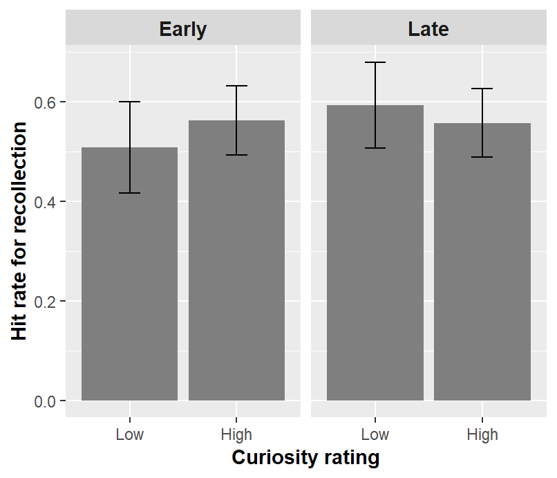

Figure 7. Mean hit rate as a function of item order (Early vs. Late) and curiosity (Low vs. High).

#### 4.2.3.1 Stats on it

```
##                  Model df       AIC        BIC   logLik   Test   L.Ratio
## baseline             1  5 -25.80514 -10.685740 17.90257
## curiosityModel       2  6 -23.95447  -5.811187 17.97724 1 vs 2 0.1493275
## orderModel           3  7 -23.82487  -2.657705 18.91243 2 vs 3 1.8703990
## interactionModel     4  8 -24.55655  -0.365507 20.27828 3 vs 4 2.7316818
##                  p-value
## baseline
## curiosityModel    0.6992
## orderModel        0.1714
## interactionModel  0.0984
```

No significant.

#### 4.2.3.2 Linear trend respectivley for High and Low curiosity groups

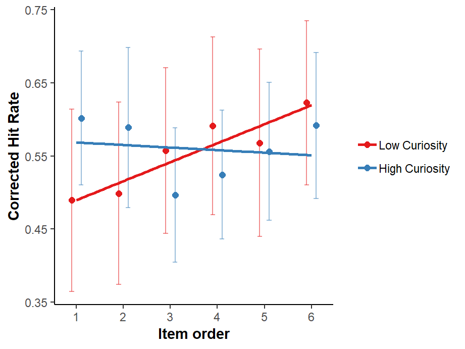

```r
Encoding.Recall.Old.CuriosityType$ItemOrderCt <- Encoding.Recall.Old.CuriosityType$ItemOrder - 1

baseline <- lme(CorrSeenHit ~ 1, random = ~ 1|SubjectNo/CuriosityRatingType, data = Encoding.Recall.Old.CuriosityType[!SubjectNo %in% bad.ps.less.strict], method = "ML", control = list(msMaxIter = 500, opt = "optim", msVerbose=FALSE), na.action = na.exclude)

orderModel.linear.1   <- update(baseline,              .~. + ItemOrderCt)
orderModel.linear.2   <- update(orderModel.linear.1,   random = ~ 1 + ItemOrderCt|SubjectNo/CuriosityRatingType)

curiosityModel        <- update(orderModel.linear.2,   .~. + CuriosityRatingType)
curiosityModel.linear <- update(curiosityModel,        .~. + CuriosityRatingType : ItemOrderCt)

anova(baseline, orderModel.linear.1, orderModel.linear.2, curiosityModel, curiosityModel.linear)
```

```
##                       Model df      AIC      BIC    logLik   Test  L.Ratio
## baseline                  1  4 222.1852 238.6751 -107.0926
## orderModel.linear.1       2  5 222.3479 242.9604 -106.1740 1 vs 2 1.837214
## orderModel.linear.2       3  9 226.9692 264.0716 -104.4846 2 vs 3 3.378741
## curiosityModel            4 10 228.8942 270.1191 -104.4471 3 vs 4 0.075036
## curiosityModel.linear     5 11 227.1691 272.5165 -102.5846 4 vs 5 3.725053
##                       p-value
## baseline
## orderModel.linear.1    0.1753
## orderModel.linear.2    0.4966
## curiosityModel         0.7841
## curiosityModel.linear  0.0536
```

There was a marginally signficant interaction, *p* = 0.054.

```r
summary(curiosityModel.linear)$tTable
```

```
##                                           Value  Std.Error  DF   t-value
## (Intercept)                          0.48716626 0.04492973 378 10.842849
## ItemOrderCt                          0.02566618 0.01223806 378  2.097244
## CuriosityRatingTypeHigh              0.08153443 0.05011226  35  1.627036
## ItemOrderCt:CuriosityRatingTypeHigh -0.02916222 0.01512784 378 -1.927719
##                                          p-value
## (Intercept)                         4.934626e-24
## ItemOrderCt                         3.663580e-02
## CuriosityRatingTypeHigh             1.127004e-01
## ItemOrderCt:CuriosityRatingTypeHigh 5.463901e-02
```

For low curiosity, there was a significant positive correlation with item order, *p* = 0.037, which was marginally steeper than high curiosity group, *p* = 0.055.

### 4.2.4 Try another way to calculate “High” and “Low” curiosity groups

> “High” - higher than mean; “Low” - lower than mean

#### 4.2.4.1 Compare “High” and “Low” groups

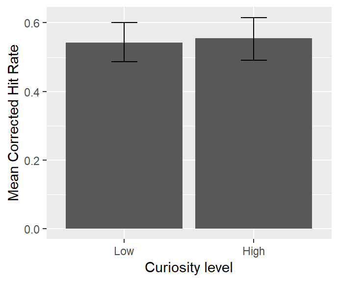

```
##
##  Paired t-test
##
## data:  CorrSeenHit by RatingGroup
## t = -0.43194, df = 39, p-value = 0.6682
## alternative hypothesis: true difference in means is not equal to 0
## 95 percent confidence interval:
##  -0.07182375  0.04654597
## sample estimates:
## mean of the differences
##             -0.01263889
```

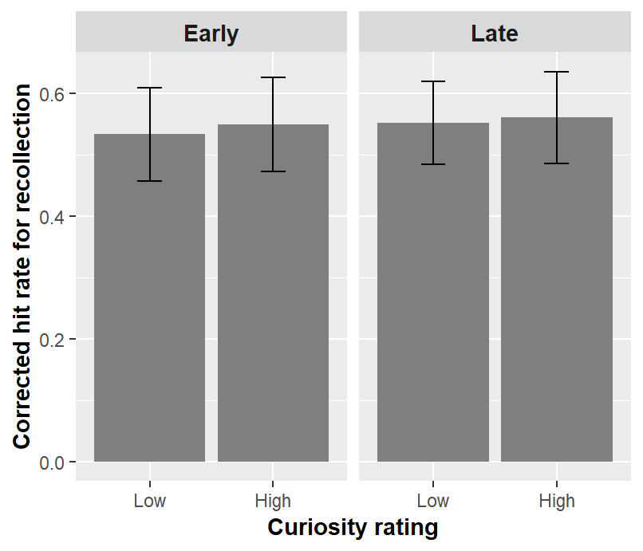

#### 4.2.4.2 Stats on it

```
##                  Model df       AIC       BIC   logLik   Test   L.Ratio
## baseline             1  5 -55.68864 -40.31277 32.84432
## curiosityModel       2  6 -53.87595 -35.42490 32.93797 1 vs 2 0.1873117
## orderModel           3  7 -52.25409 -30.72788 33.12705 2 vs 3 0.3781464
## interactionModel     4  8 -50.27313 -25.67174 33.13657 3 vs 4 0.0190364
##                  p-value
## baseline
## curiosityModel    0.6652
## orderModel        0.5386
## interactionModel  0.8903
```

No significant main effects.

#### 4.2.4.3 Linear trend respectivley for High and Low curiosity groups

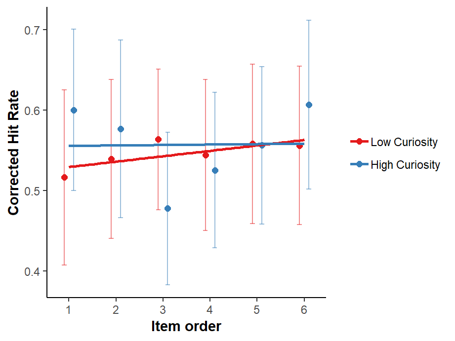

```r
Encoding.Recall.Old.CuriosityType.MeanSep$ItemOrderCt <- Encoding.Recall.Old.CuriosityType.MeanSep$ItemOrder - 1

baseline <- lme(CorrSeenHit ~ 1, random = ~ 1|SubjectNo/RatingGroup, data = Encoding.Recall.Old.CuriosityType.MeanSep[!SubjectNo %in% bad.ps.less.strict], method = "ML", control = list(msMaxIter = 500, opt = "optim", msVerbose=FALSE), na.action = na.exclude)

orderModel.linear.1   <- update(baseline,              .~. + ItemOrderCt)
orderModel.linear.2   <- update(orderModel.linear.1,   random = ~ 1 + ItemOrderCt|SubjectNo/RatingGroup)

curiosityModel        <- update(orderModel.linear.2,   .~. + RatingGroup)
curiosityModel.linear <- update(curiosityModel,        .~. + RatingGroup : ItemOrderCt)

anova(baseline, orderModel.linear.1, orderModel.linear.2, curiosityModel, curiosityModel.linear)
```

```
##                       Model df      AIC      BIC    logLik   Test  L.Ratio
## baseline                  1  4 160.9714 177.6665 -76.48568
## orderModel.linear.1       2  5 162.6997 183.5686 -76.34986 1 vs 2 0.271653
## orderModel.linear.2       3  9 166.3339 203.8980 -74.16694 2 vs 3 4.365835
## curiosityModel            4 10 168.1849 209.9227 -74.09243 3 vs 4 0.149017
## curiosityModel.linear     5 11 169.9770 215.8887 -73.98852 4 vs 5 0.207827
##                       p-value
## baseline
## orderModel.linear.1    0.6022
## orderModel.linear.2    0.3588
## curiosityModel         0.6995
## curiosityModel.linear  0.6485
```

No significant main effect.

# 5 Curiosity and novelty

## 5.1 Testing the effects of curiosity rating and novelty together

Build models with item memory accuracy as $y$ and examine effects of curiosity rating and novelty together by including them into the model separately and then comparing the model fits.

```
##                   Model df       AIC       BIC   logLik   Test   L.Ratio
## baseline.rating       1  4 -21.58231 -7.726983 14.79115
## rating.intercept      2  5 -20.31640 -2.997239 15.15820 1 vs 2 0.7340874
## rating.slope          3  9 -14.24504 16.929443 16.12252 2 vs 3 1.9286447
## novelty.model.1       4 10 -12.28227 22.356048 16.14113 3 vs 4 0.0372275
## interaction.model     5 11 -11.14696 26.955193 16.57348 4 vs 5 0.8646863
##                   p-value
## baseline.rating
## rating.intercept   0.3916
## rating.slope       0.7489
## novelty.model.1    0.8470
## interaction.model  0.3524
```

### 5.1.1 Check the complete model

```
##                                  Value  Std.Error  DF    t-value
## (Intercept)                 0.50068760 0.04856038 154 10.3106193
## CuriosityRating             0.01623260 0.01463553 154  1.1091226
## GroupNovel                  0.10484238 0.13083715  39  0.8013197
## CuriosityRating:GroupNovel -0.02300015 0.02492264 154 -0.9228617
##                                 p-value
## (Intercept)                2.782498e-19
## CuriosityRating            2.691063e-01
## GroupNovel                 4.278019e-01
## CuriosityRating:GroupNovel 3.575229e-01
```

## 5.2 What about the other way around

```
##                   Model df       AIC       BIC   logLik   Test   L.Ratio
## baseline.rating       1  4 -21.58231 -7.726983 14.79115
## novelty.model.1       2  5 -19.99883 -2.679676 14.99942 1 vs 2 0.4165241
## rating.model.1        3  6 -18.32711  2.455882 15.16355 2 vs 3 0.3282737
## rating.model.2        4 10 -12.28227 22.356048 16.14113 3 vs 4 1.9551619
## interaction.model     5 11 -11.14696 26.955193 16.57348 4 vs 5 0.8646862
##                   p-value
## baseline.rating
## novelty.model.1    0.5187
## rating.model.1     0.5667
## rating.model.2     0.7440
## interaction.model  0.3524
```

### 5.2.1 Check the complete model

```
##                                  Value  Std.Error  DF    t-value
## (Intercept)                 0.50068760 0.04856038 154 10.3106193
## GroupNovel                  0.10484238 0.13083715  39  0.8013197
## CuriosityRating             0.01623260 0.01463553 154  1.1091226
## GroupNovel:CuriosityRating -0.02300015 0.02492264 154 -0.9228617
##                                 p-value
## (Intercept)                2.782498e-19
## GroupNovel                 4.278019e-01
## CuriosityRating            2.691063e-01
## GroupNovel:CuriosityRating 3.575229e-01
```

## 5.3 Check the collapsed data

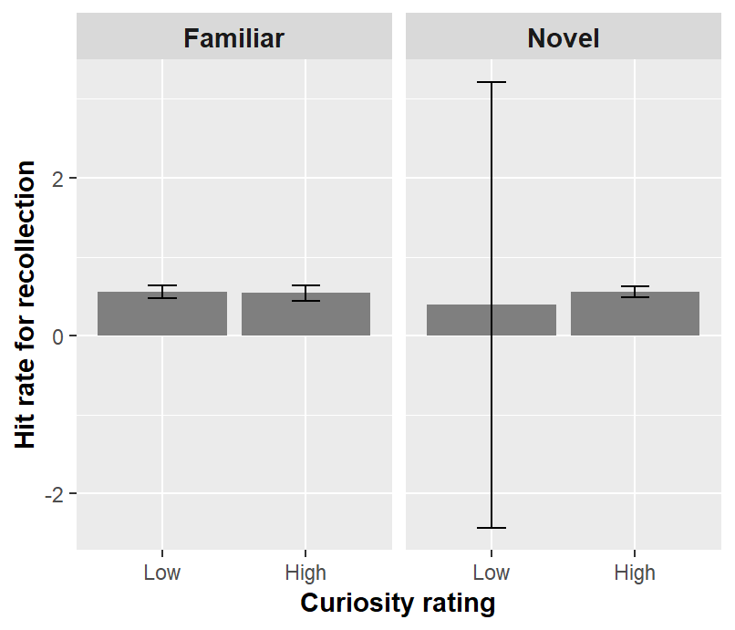

### 5.3.1 Alternative way to collapse data

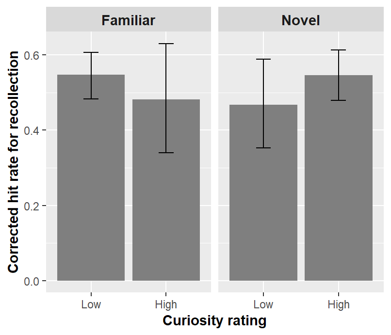

```
##                  Model df       AIC       BIC   logLik   Test    L.Ratio
## baseline             1  5 -43.78345 -31.01406 26.89172
## curiosityModel       2  6 -41.78365 -26.46039 26.89182 1 vs 2 0.00020265
## noveltyModel         3  7 -39.78562 -21.90848 26.89281 2 vs 3 0.00196822
## interactionModel     4  8 -37.86418 -17.43317 26.93209 3 vs 4 0.07856638
##                  p-value
## baseline
## curiosityModel    0.9886
## noveltyModel      0.9646
## interactionModel  0.7792
```

No significant main effect.

# 6 Curiosity effects in the *Novel* group

## 6.1 Mean accuracy of item memory as a function of curiosity rating

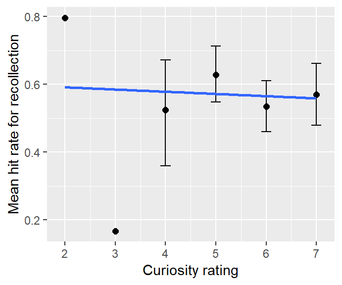